# Goals

### Question 4.5

Plot a bar chart to show the percentage of delayed flights over months in a year. Discuss your findings from the figure.

```python
# FLIGHTS PER MONTH
res = sqlContext.sql("SELECT month, COUNT(*) AS number_of_flights FROM flights GROUP BY month ORDER BY month")
res.show()

flights_per_month = df.groupBy(df.month).count().orderBy(df.month).collect()
#print("Total number of flights per month: {}".format(str(flights_per_month)))
```

```
+-----+-----------------+
|month|number_of_flights|
+-----+-----------------+
|    1|           423861|
|    2|           386954|
|    3|           435516|
|    4|           420995|
|    5|           436432|
|    6|           426490|
|    7|           443736|
|    8|           451086|
|    9|           430861|
|   10|           449369|
|   11|           428227|
|   12|           446521|
+-----+-----------------+
```

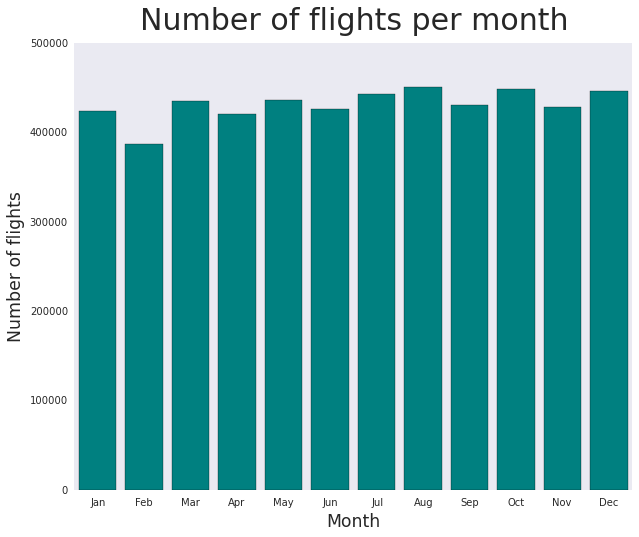

```python
y_data = query_column(flights_per_month, 1)

barchart_simple("Number of flights per month", MONTHS_SHORT, y_data, "Month", "Number of flights")
```

**Observation**  
This is the "bar" version of the first graph we have done (a linechart)

```python
# DELAYED FLIGHTS PER MONTH
res = sqlContext.sql("SELECT month, COUNT(*) AS res FROM flights WHERE arrival_delay > 15 GROUP BY month ORDER BY month")
res.show()

delayed_per_month = df.filter(df.arrival_delay > 15)\
                            .groupBy(df.month).count().orderBy(df.month).collect()

#print("Number of delayed flights per month: {}".format(str(delayed_per_month)))
```

```
+-----+-----+
|month|  res|
+-----+-----+
|    1|97957|
|    2|78600|
|    3|65260|
|    4|63986|
|    5|47542|
|    6|69084|
|    7|81022|
|    8|64893|
|    9|45590|
|   10|55901|
|   11|73947|
|   12|82083|
+-----+-----+
```

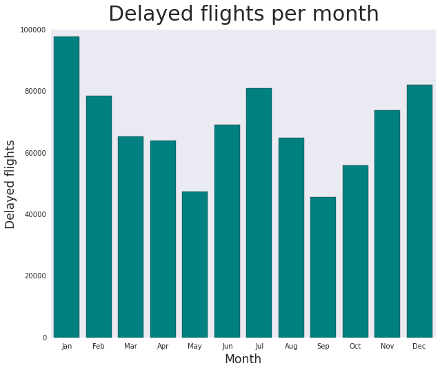

```python
y_data = query_column(delayed_per_month, 1)

barchart_simple("Delayed flights per month", MONTHS_SHORT, y_data, "Month", "Delayed flights")
```

```python
# COMPUTING THE PERCENTAGE OF THE DELAYED FLIGHTS PER MONTH
print('Percentages of delayed flights per month:')

percentage_delayed_flight_month = [[x[0]-1 for x in delayed_per_month], []]

percentage_delayed_flight_day_week
for num, val in enumerate(zip(flights_per_month, delayed_per_month)):
    perc =  __builtin__.round(val[1][1] / val[0][1]*100, 2)
    percentage_delayed_flight_month[1].append(perc)
    #print("- month {}: {}%".format(num+1, perc))
```

```
Percentages of delayed flights per month:
```

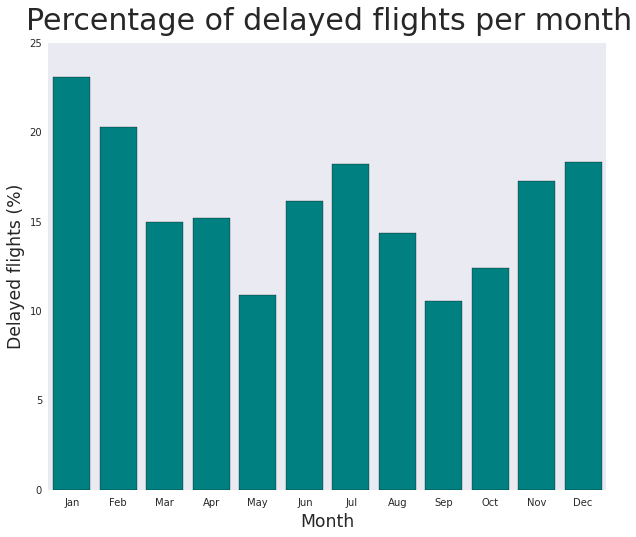

```python
barchart_simple("Percentage of delayed flights per month", MONTHS_SHORT, percentage_delayed_flight_month[1], "Month", "Delayed flights (%)")
```

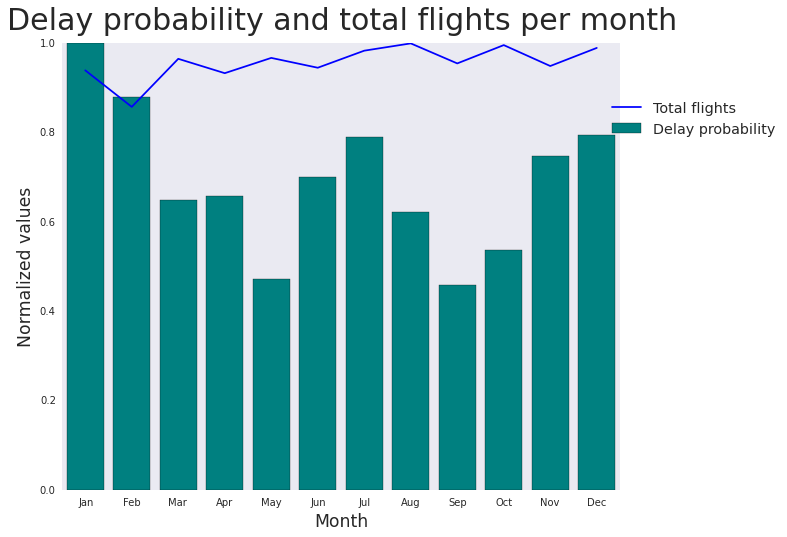

```python
y_data = query_column(flights_per_month, 1)
barchart_and_linechart("Delay probability and total flights per month", MONTHS_SHORT, percentage_delayed_flight_month[1], y_data, "Month", "Delay probability", "Total flights")
```

**Interpretation**  
Because the two shapes are very different, we can state that a correlation between month and flight delays exists.  
Anyway, we should investigate more to understand the reason (as said before, we think it is correlated with seasons: maybe it is due to weather, or the tourism activity)

We are ready now to draw some observations from our data, even if we have only looked at data coming from a year worth of flights:

- The probability for a flight to be delayed is low at the beginning or at the very end of a given months
- Flights on two first weekdays and on the weekend, are less likely to be delayed
- May and September are very good months for travelling, as the probability of delay is low (remember we're working on US data. Do you think this is also true in France?)

Putting things together, we can have a global picture of the whole year!

```python
df_with_delay = df.withColumn('is_delay', when(df["arrival_delay"] >= 15, 1).otherwise(0))
statistic_day = df_with_delay.groupBy(['year','month', 'day_of_month', 'day_of_week'])\
    .agg((func.sum('is_delay')/func.count('*')).alias('delay_ratio'))

# assume that we do statistic on year 1994
statistic_day = statistic_day\
    .orderBy('year', 'month', 'day_of_month', 'day_of_week')
pdf = pd.DataFrame(data=statistic_day.collect())
```

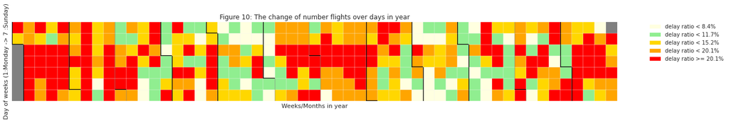

```python
fig = plt.figure(figsize=(20,10))
ax = fig.add_subplot(1,1,1)
plt.xlabel("Weeks/Months in year")
plt.ylabel("Day of weeks (1:Monday -> 7 :Sunday)")
plt.title('Figure 10: The change of number flights over days in year')

rec_size = 0.3
from matplotlib.patches import Rectangle
import datetime
num_days = len(pdf[0])
ax.patch.set_facecolor('gray')
ax.set_aspect('equal', 'box')
ax.xaxis.set_major_locator(plt.NullLocator())
ax.yaxis.set_major_locator(plt.NullLocator())

for i in range(0, num_days):
    # extract information from the result
    year = pdf[0][i]
    month = pdf[1][i]
    day_of_month = pdf[2][i]
    day_of_week = pdf[3][i]
    day_of_year= datetime.date(year=year, month=month, day=day_of_month).timetuple()
    week_of_year = datetime.date(year=year, month=month, day=day_of_month).isocalendar()[1]

    # dealing with the week of the previous year
    if week_of_year == 52 and month == 1:
        week_of_year = 0

    # the coordinate of a day in graph
    X = week_of_year*rec_size
    Y = day_of_week*rec_size

    # use different colors to show the delay ratio
    color = 'white'
    if pdf[4][i] <= 0.084:
        color = 'lightyellow'
    elif pdf[4][i] <= 0.117:
        color = 'lightgreen'
    elif pdf[4][i] <= 0.152:
        color = 'gold'
    elif pdf[4][i] <= 0.201:
        color = 'orange'
    else:
        color = 'red'
    rect = plt.Rectangle((X - rec_size/2.0, Y - rec_size/2.0), rec_size, rec_size,
                      alpha=1, facecolor=color, edgecolor='whitesmoke')

    ax.add_patch(rect)

    # drawing boders to separate months
    if day_of_month <= 7:
        rect2 = plt.Rectangle((X -rec_size/2.0, Y - rec_size/2.0), 0.01, rec_size,
                      alpha=1, facecolor='black')
        ax.add_patch(rect2)
    if day_of_month == 1:
        rect2 = plt.Rectangle((X - rec_size/2.0, Y - rec_size/2.0), rec_size, 0.01,
                      alpha=1, facecolor='black')
        ax.add_patch(rect2)
ax.autoscale_view()

patch1 = mpatches.Patch(color='lightyellow', label='delay ratio < 8.4%')
patch2 = mpatches.Patch(color='lightgreen', label='delay ratio < 11.7%')
patch3 = mpatches.Patch(color='gold', label='delay ratio < 15.2%')
patch4 = mpatches.Patch(color='orange', label='delay ratio < 20.1%')
patch5 = mpatches.Patch(color='red', label='delay ratio >= 20.1%')

plt.legend(handles=[patch1, patch2, patch3, patch4, patch5], bbox_to_anchor=(1.05, 1), loc=2, borderaxespad=0.)

plt.show()
```

### Question 4.6

What is the delay probability for the top 20 busiest airports? By drawing the flight volume of each airport and the associated delay probability in a single plot, we can observe the relationship between airports, number of flights and the delay.

HINT

Function `.isin()` helps checking whether a value in column belongs to a list.

SUGGESTION

You can try with different chart type to have a better visualization.

```python
# DELAYED FLIGHTS PER AIRPORT, IN 1994
delayed_in_flights_per_airport = "SELECT src_airport, COUNT(*) AS number_of_in_flights FROM flights WHERE arrival_delay > 15 GROUP BY src_airport"
delayed_out_flights_per_airport = "SELECT dest_airport, COUNT(*) AS number_of_out_flights FROM flights WHERE arrival_delay > 15 GROUP BY dest_airport"
delayed_flights_per_airport = sqlContext.sql("SELECT src_airport AS airport_id, number_of_in_flights + number_of_out_flights AS delayed_flights FROM ({}), ({}) WHERE src_airport = dest_airport ORDER BY src_airport".format(delayed_in_flights_per_airport, delayed_out_flights_per_airport))

delayed_flights_per_airport.show()
```

```
+----------+---------------+
|airport_id|delayed_flights|
+----------+---------------+
|       ABE|           1636|
|       ABQ|           8898|
|       ACK|             13|
|       ACY|            108|
|       ADQ|            143|
|       AGS|            946|
|       AKN|            125|
|       ALB|           3707|
|       AMA|           1204|
|       ANC|           5794|
|       ANI|             24|
|       ATL|          85768|
|       AUS|           8089|
|       AVL|            906|
|       AVP|            838|
|       AZO|            539|
|       BDL|           7724|
|       BET|            233|
|       BFL|            224|
|       BGM|            401|
+----------+---------------+
only showing top 20 rows
```

```python
# DELAYED FLIGHTS PER TOP 20 BUSIEST AIRPORT, IN 1994
# Dataframe "top20_total_in_out" contains the top 20 busiest airports
# Airport_Id, number_of_flights
top20_list = list(map(lambda x: x['airport_id'], top20_total_in_out.select('airport_id').take(20)))

# retrieve information, maintaining airport IATA codes ordered according to the top-20 ranking
top20_airports_with_delay = delayed_flights_per_airport\
                                            .filter(col('airport_id').isin(top20_list))\
                                            .join(top20_total_in_out, 'airport_id')\
                                            .orderBy('count_in_out', ascending=False)

delayed_flights_per_busiest_airport = top20_airports_with_delay.select('airport_id', 'delayed_flights')
delayed_flights_per_busiest_airport.show()
```

```
+----------+---------------+
|airport_id|delayed_flights|
+----------+---------------+
|       ORD|          82369|
|       DFW|          98872|
|       ATL|          85768|
|       LAX|          52923|
|       STL|          48355|
|       DEN|          52567|
|       PHX|          43606|
|       DTW|          38562|
|       PIT|          47697|
|       CLT|          45456|
|       MSP|          32610|
|       SFO|          40946|
|       EWR|          58558|
|       IAH|          32535|
|       LGA|          35605|
|       BOS|          41413|
|       LAS|          30492|
|       PHL|          35863|
|       DCA|          26664|
|       MCO|          25617|
+----------+---------------+
```

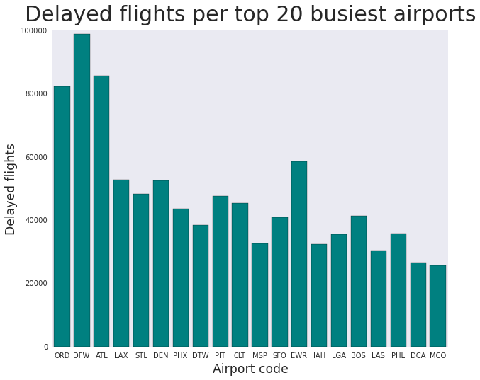

```python
res = delayed_flights_per_busiest_airport.collect()
x_names = query_column(res, 0)
y_data = query_column(res, 1)

barchart_simple("Delayed flights per top 20 busiest airports", x_names, y_data, "Airport code", "Delayed flights")
```

```python
# DELAY PROBABILITY FOR THE TOP 20 BUSIEST AIRPORTS, IN 1994
delay_probability_per_busiest_airports = top20_airports_with_delay\
                                            .select('airport_id', (top20_airports_with_delay.delayed_flights / top20_airports_with_delay.count_in_out).alias('delay_prob'))

delay_probability_per_busiest_airports.show()
```

```
+----------+-------------------+
|airport_id|         delay_prob|
+----------+-------------------+
|       ORD|0.14670475776590003|
|       DFW| 0.1914183879517466|
|       ATL|  0.193574888167665|
|       LAX|0.17269532358958797|
|       STL|0.15884878567979266|
|       DEN|0.18410582573916212|
|       PHX| 0.1554248645566011|
|       DTW|0.13957983436613192|
|       PIT|0.18139948809419676|
|       CLT| 0.1750246426811237|
|       MSP|0.13150254052746188|
|       SFO|0.17388460917792745|
|       EWR|0.25025748853588387|
|       IAH|0.15597509000867726|
|       LGA| 0.1750818737030517|
|       BOS| 0.2073802179312555|
|       LAS|0.16055181128896379|
|       PHL| 0.1918864401247746|
|       DCA|0.15140107316242227|
|       MCO| 0.1666471506635441|
+----------+-------------------+
```

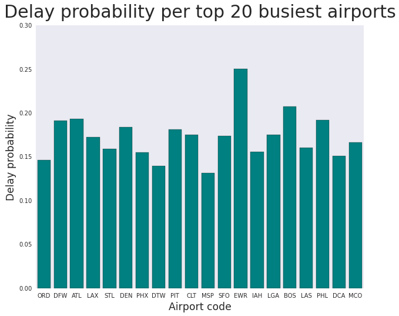

```python
res = delay_probability_per_busiest_airports.collect()
x_names = query_column(res, 0)
y_data = query_column(res, 1)

barchart_simple("Delay probability per top 20 busiest airports", x_names, y_data, "Airport code", "Delay probability")
```

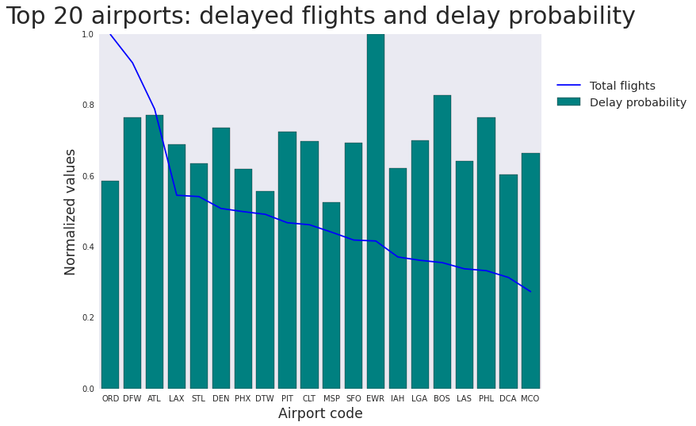

```python
line_data = query_column(top20_total_in_out.take(20), 1)

barchart_and_linechart("Top 20 airports: delayed flights and delay probability", x_names, y_data, line_data, "Airport code", "Delay probability", "Total flights", box_x=1.35)
```

**Interpretation**  
We can see that the delay probability for the top 20 airports is not specifically related to the number of flights that arrive at/departure from it.  
It's interesting to notice that the most crowded airport has one of the lowest associated delay probability value. What we can state is that the delay probability depends on the airport: which means that crucial factors of delay could be characteristics like the internal logistics efficiency, the availability of resources, the training level and experience of the workers or the weather that affects the area where the airport is.  
In order to determine which of these possible feature has a major impact of the result, more information and a further analysis are needed

### Question 4.7

What is the percentage of delayed flights which belong to one of the top 20 busiest carriers? Comment the figure!

SUGGESTION

You can try with different chart type to have a better visualization.

```python
# DELAYED FLIGHTS PER CARRIER, IN 1994
delayed_flights_per_carrier = sqlContext.sql("SELECT carrier, COUNT(*) AS delayed_flights FROM flights WHERE arrival_delay > 15 GROUP BY carrier ORDER BY carrier")
delayed_flights_per_carrier.show()
```

```
+-------+---------------+
|carrier|delayed_flights|
+-------+---------------+
|     AA|         119390|
|     AS|          16910|
|     CO|          89421|
|     DL|         148181|
|     HP|          30701|
|     NW|          58811|
|     TW|          44193|
|     UA|         101438|
|     US|         148540|
|     WN|          68280|
+-------+---------------+
```

```python
# DELAYED FLIGHTS PER TOP20 BUSIEST CARRIERS, in 1994
# Note: the code below would have worked also if carriers were more than 20. We know that, in our case, carriers are less: but we wanted to leave here a more complex solution
top20_list = list(map(lambda x: x['carrier'], top20_carriers.take(20)))

# We want that carriers position on the x-axis corresponds to their top-20 ranking
top20_carriers_with_delay = delayed_flights_per_carrier\
                                .filter(col('carrier').isin(top20_list))\
                                .join(top20_carriers, 'carrier')\
                                .orderBy('number_of_flights', ascending=False)

res = top20_carriers_with_delay.select('carrier', 'delayed_flights')
res.show()

delayed_flights_per_busiest_carrier = res.collect()
```

```
+-------+---------------+
|carrier|delayed_flights|
+-------+---------------+
|     DL|         148181|
|     US|         148540|
|     AA|         119390|
|     UA|         101438|
|     WN|          68280|
|     CO|          89421|
|     NW|          58811|
|     TW|          44193|
|     HP|          30701|
|     AS|          16910|
+-------+---------------+
```

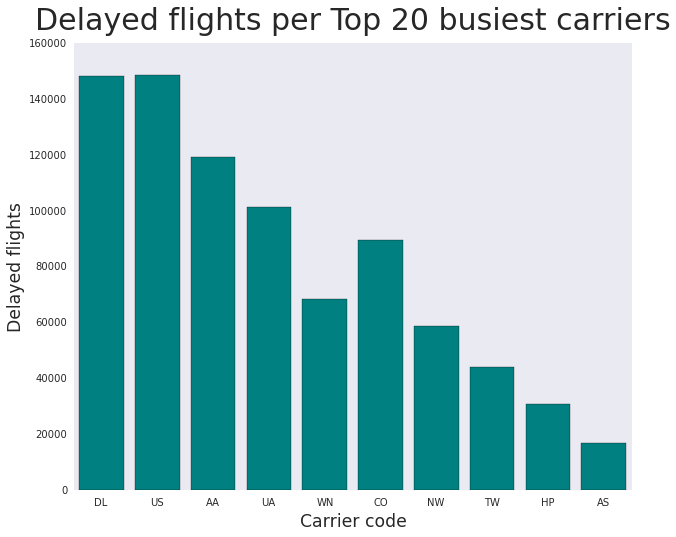

```python
x_names = query_column(delayed_flights_per_busiest_carrier, 0)
y_data = query_column(delayed_flights_per_busiest_carrier, 1)

barchart_simple("Delayed flights per Top 20 busiest carriers", x_names, y_data, "Carrier code", "Delayed flights")
```

**Interpretation**  
We can see a relation between the size (top-20 rank) of carriers and their quantity of delayed flights: the biggest ones are those with most delayed flights.  
"CO" carrier is an exception

```python
# DELAY PROBABILITY FOR THE TOP 20 BUSIEST AIRPORTS, IN 1994
delay_probability_per_busiest_carriers = top20_carriers_with_delay\
                                            .select('carrier', (top20_carriers_with_delay.delayed_flights / top20_carriers_with_delay.number_of_flights).alias('delay_prob'))
delay_probability_per_busiest_carriers.show()

# dataframe is no longer needed
delay_probability_per_busiest_carriers = delay_probability_per_busiest_carriers.collect()
```

```
+-------+-------------------+
|carrier|         delay_prob|
+-------+-------------------+
|     DL| 0.1694415031685736|
|     US|0.17314251211671208|
|     AA|0.16529669365077387|
|     UA|0.15880704500978474|
|     WN|0.12075850774460319|
|     CO|0.18443632253513573|
|     NW|0.12181284926615271|
|     TW|0.17115470265874014|
|     HP|0.17262202630291648|
|     AS|0.14394552032347308|
+-------+-------------------+
```

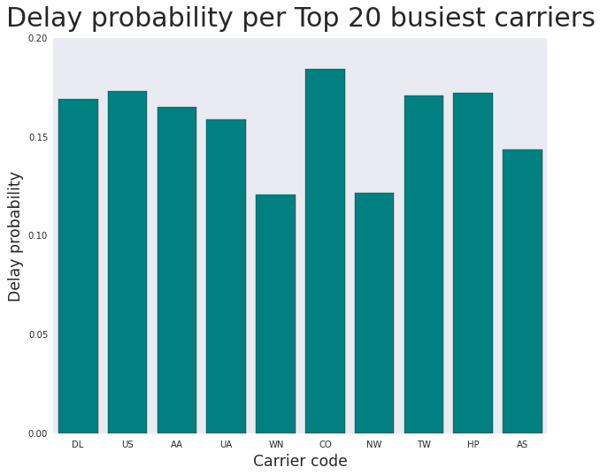

```python
x_names = query_column(delay_probability_per_busiest_carriers, 0)
y_data = query_column(delay_probability_per_busiest_carriers, 1)

barchart_simple("Delay probability per Top 20 busiest carriers", x_names, y_data, "Carrier code", "Delay probability")
```

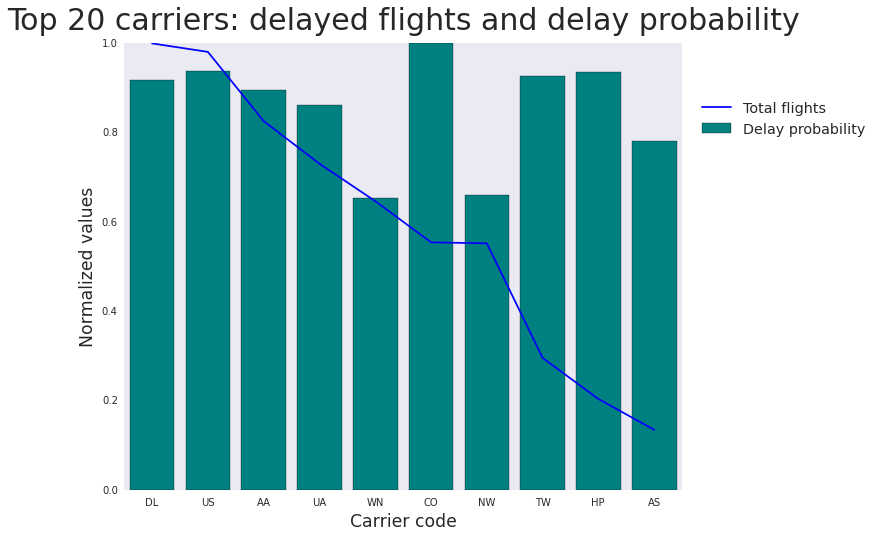

```python
line_data = query_column(top20_carriers.collect(), 1)

barchart_and_linechart("Top 20 carriers: delayed flights and delay probability", x_names, y_data, line_data, "Carrier code", "Delay probability", "Total flights", box_x=1.35)
```

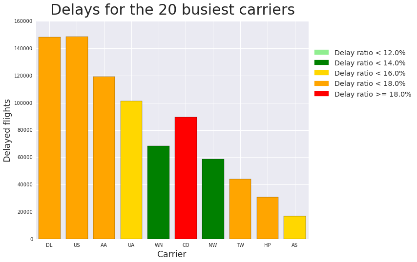

```python
# titles
title = "Delays for the 20 busiest carriers"
x_label = "Carrier"
y_label = "Delayed flights"
legend_label = "Delay ratio"
# data
carrier_names = query_column(delay_probability_per_busiest_carriers, 0)
y_data = query_column(delayed_flights_per_busiest_carrier, 1)    # heights for the bars
color_data = query_column(delay_probability_per_busiest_carriers, 1)    # data used to give the bars a color

# create the barchart
barchart_colored(title, carrier_names, y_data, color_data, x_label, y_label, legend_label, box_x=1.4, thresholds=[0.12, 0.14, 0.16, 0.18])
```

**Interpretation**  
This graph is a different graphical way to highlight what we have stated before: regardless to their size, some carriers have worst performance in terms of delay probability of their flights

## Addition (bonus) questions

### Additional data

In the HDFS file system you have used for running the Notebook, you will notice that there are several other years available (in addition to 1994).

There are some other datasets that related to this use case:

- Airport IATA Codes to City names and Coordinates mapping: http://stat-computing.org/dataexpo/2009/airports.csv
- Carrier codes to Full name mapping: http://stat-computing.org/dataexpo/2009/carriers.csv
- Information about individual planes: http://stat-computing.org/dataexpo/2009/plane-data.csv
- Weather information: http://www.wunderground.com/weather/api/. You can subscribe for free to the developers' API and obtain (at a limited rate) historical weather information in many different formats. Also, to get an idea of the kind of information is available, you can use this link: http://www.wunderground.com/history/

```python
# LOAD AIRPORT CODES MAPPING
df_iata = sqlContext.read.option('header','true').csv('./datasets/airports.csv')\
                .withColumn('lat', col('lat').cast('double'))\
                .withColumn('long', col('long').cast('double'))

#print(df_iata.schema)
df_iata.show(5)
```

```
+----+--------------------+----------------+-----+-------+-----------+------------+
|iata|             airport|            city|state|country|        lat|        long|
+----+--------------------+----------------+-----+-------+-----------+------------+
| 00M|            Thigpen |     Bay Springs|   MS|    USA|31.95376472|-89.23450472|
| 00R|Livingston Municipal|      Livingston|   TX|    USA|30.68586111|-95.01792778|
| 00V|         Meadow Lake|Colorado Springs|   CO|    USA|38.94574889|-104.5698933|
| 01G|        Perry-Warsaw|           Perry|   NY|    USA|42.74134667|-78.05208056|
| 01J|    Hilliard Airpark|        Hilliard|   FL|    USA| 30.6880125|-81.90594389|
+----+--------------------+----------------+-----+-------+-----------+------------+
only showing top 5 rows
```

```python
# LOAD CARRIER CODE MAPPING
df_carriers = sqlContext.read.option('header','true').csv('./datasets/carriers.csv')

#print(df_carriers.schema)
df_carriers.show(5)
```

```
+----+--------------------+
|Code|         Description|
+----+--------------------+
| 02Q|       Titan Airways|
| 04Q|  Tradewind Aviation|
| 05Q| Comlux Aviation, AG|
| 06Q|Master Top Linhas...|
| 07Q| Flair Airlines Ltd.|
+----+--------------------+
only showing top 5 rows
```

```python
# LOAD PLANES INFORMATION
df_planes = sqlContext.read.option('header','true').csv('./datasets/plane-data.csv').filter(col('type') != '')\
                .withColumn('year', col('year').cast('int'))

print(df_planes.schema)
df_planes.show(5)
```

```
StructType(List(StructField(tailnum,StringType,true),StructField(type,StringType,true),StructField(manufacturer,StringType,true),StructField(issue_date,StringType,true),StructField(model,StringType,true),StructField(status,StringType,true),StructField(aircraft_type,StringType,true),StructField(engin…
+-------+-----------+----------------+----------+---------+------+--------------------+-----------+----+
|tailnum|       type|    manufacturer|issue_date|    model|status|       aircraft_type|engine_type|year|
+-------+-----------+----------------+----------+---------+------+--------------------+-----------+----+
| N10156|Corporation|         EMBRAER|02/13/2004|EMB-145XR| Valid|Fixed Wing Multi-...|  Turbo-Fan|2004|
| N102UW|Corporation|AIRBUS INDUSTRIE|05/26/1999| A320-214| Valid|Fixed Wing Multi-...|  Turbo-Fan|1998|
| N10323|Corporation|          BOEING|07/01/1997|  737-3TO| Valid|Fixed Wing Multi-...|  Turbo-Jet|1986|
| N103US|Corporation|AIRBUS INDUSTRIE|06/18/1999| A320-214| Valid|Fixed Wing Multi-...|  Turbo-Fan|1999|
| N104UA|Corporation|          BOEING|01/26/1998|  747-422| Valid|Fixed Wing Multi-...|  Turbo-Fan|1998|
+-------+-----------+----------------+----------+---------+------+--------------------+-----------+----+
only showing top 5 rows
```

```python
# CREATE THE FULL DATAFRAME (flights for every available year)
df_full = sqlContext.read.load('/datasets/airline/2008.csv',
        format='com.databricks.spark.csv',
        header='true',
        inferSchema='true',
        nullValue='NA'
    )
years_to_load = list(range(1987, 2007))

for year in years_to_load:
    df_current_year = sqlContext.read.load('/datasets/airline/' + str(year) + '.csv',
        format='com.databricks.spark.csv',
        header='true',
        inferSchema='true',
        nullValue='NA'
    )
    df_full = df_full.union(df_current_year)

del df_current_year
df_full.show(5)

df_full.createOrReplaceTempView("flights_full")
```

```
+----+-----+----------+---------+-------+----------+-------+----------+-------------+---------+-------+-----------------+--------------+-------+--------+--------+------+----+--------+------+-------+---------+----------------+--------+------------+------------+--------+-------------+-----------------…
|Year|Month|DayofMonth|DayOfWeek|DepTime|CRSDepTime|ArrTime|CRSArrTime|UniqueCarrier|FlightNum|TailNum|ActualElapsedTime|CRSElapsedTime|AirTime|ArrDelay|DepDelay|Origin|Dest|Distance|TaxiIn|TaxiOut|Cancelled|CancellationCode|Diverted|CarrierDelay|WeatherDelay|NASDelay|SecurityDelay|LateAircraftDelay…
+----+-----+----------+---------+-------+----------+-------+----------+-------------+---------+-------+-----------------+--------------+-------+--------+--------+------+----+--------+------+-------+---------+----------------+--------+------------+------------+--------+-------------+-----------------…
|2008|    1|         3|        4|   2003|      1955|   2211|      2225|           WN|      335| N712SW|              128|           150|    116|     -14|       8|   IAD| TPA|     810|     4|      8|        0|            null|       0|        null|        null|    null|         null|             null…
|2008|    1|         3|        4|    754|       735|   1002|      1000|           WN|     3231| N772SW|              128|           145|    113|       2|      19|   IAD| TPA|     810|     5|     10|        0|            null|       0|        null|        null|    null|         null|             null…
|2008|    1|         3|        4|    628|       620|    804|       750|           WN|      448| N428WN|               96|            90|     76|      14|       8|   IND| BWI|     515|     3|     17|        0|            null|       0|        null|        null|    null|         null|             null…
|2008|    1|         3|        4|    926|       930|   1054|      1100|           WN|     1746| N612SW|               88|            90|     78|      -6|      -4|   IND| BWI|     515|     3|      7|        0|            null|       0|        null|        null|    null|         null|             null…
|2008|    1|         3|        4|   1829|      1755|   1959|      1925|           WN|     3920| N464WN|               90|            90|     77|      34|      34|   IND| BWI|     515|     3|     10|        0|            null|       0|           2|           0|       0|            0|               32…
+----+-----+----------+---------+-------+----------+-------+----------+-------------+---------+-------+-----------------+--------------+-------+--------+--------+------+----+--------+------+-------+---------+----------------+--------+------------+------------+--------+-------------+-----------------…
only showing top 5 rows
```

### Question 5.1

Which airports are present in the dataset only as destination airport? Which airport is present only as source airport in the dataset?

```python
# Retrieve the global lists
source_airports = df_full.select('Origin').distinct().orderBy('Origin')
destination_airports = df_full.select('Dest').distinct().orderBy('Dest')
src_names = source_airports.join(df_iata, source_airports.Origin == df_iata.iata).select(df_iata.airport).collect()
dst_names = destination_airports.join(df_iata, destination_airports.Dest == df_iata.iata).select(df_iata.airport).collect()

# Retrieve the result
only_src_airports = set(query_column(src_names, 0)) - set(query_column(dst_names, 0))
only_dest_airports = set(query_column(dst_names, 0)) - set(query_column(src_names, 0))

# Output the result
print("Only sources: {}".format(len(only_src_airports)))
for x in only_src_airports:
    print("- " + x)

print("\nOnly destinations: {}".format(len(only_dest_airports)))
for x in only_dest_airports:
    print("- " + x)
```

```
Only sources: 0

Only destinations: 5
- Ellsworth AFB
- Downtown
- North Platte Regional
- Fairchild AFB
- Laramie Regional
```

## Answer 5.1

There are 5 airports which are only destination ones and no airports which are only sources

### Question 5.2

Which airports have biggest delay probability ? Which cities have largest delay duration in average ?

```python
# AIRPORTS
# Retrieve data to compute the delay probability value
# note: destination airport codes are all the available airport codes

flights_per_airport = sqlContext.sql('SELECT Dest AS airportId, COUNT(*) AS totalFlights FROM flights_full GROUP BY airportId')
delayed_flights_per_airport = sqlContext.sql('SELECT Dest AS airportId, COUNT(*) AS delayedFlights FROM flights_full WHERE ArrDelay > 15 GROUP BY airportId')


# Evaluate the delay probability for each airport
delay_prob_per_airport = flights_per_airport\
                            .join(delayed_flights_per_airport, 'airportId')\
                            .select('airportId', (round(col('delayedFlights')/col('totalFlights')*100, 2)).alias('delayRatio'))\
                            .orderBy('delayRatio', ascending=False)

# Biggest delay probability values
# Let us consider the 20 biggest values
delay_prob_per_airport.show()
top20_delay_prob_per_airport = delay_prob_per_airport.take(20)
```

```
+---------+----------+
|airportId|delayRatio|
+---------+----------+
|      OTH|     42.55|
|      ACK|     35.72|
|      SOP|     35.48|
|      ILG|     35.11|
|      MQT|     34.04|
|      CKB|     33.33|
|      MCN|     29.56|
|      PVU|     28.57|
|      ADK|     28.19|
|      HHH|     27.99|
|      LMT|     27.87|
|      DHN|     27.65|
|      EGE|     27.57|
|      MAZ|     26.67|
|      BMI|      25.8|
|      VLD|     25.49|
|      DBQ|     25.22|
|      EWR|     25.04|
|      PSG|     24.93|
|      BQK|     24.88|
+---------+----------+
only showing top 20 rows
```

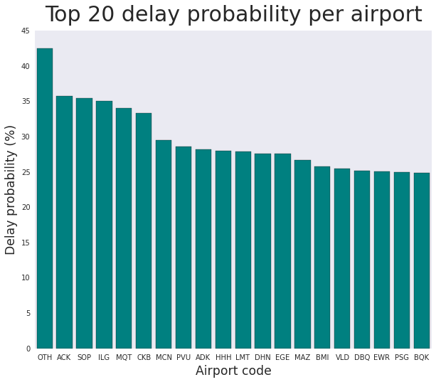

```python
x_names = query_column(top20_delay_prob_per_airport, 0)
y_data = query_column(top20_delay_prob_per_airport, 1)

barchart_simple("Top 20 delay probability per airport", x_names, y_data, "Airport code", "Delay probability (%)")
```

**Reminder**  
This is not the top 20 rank we have evaluated before: the analysis now is considering several years (dataset is larger) and the delay probability information (not the traffic, as before)

```python
# CITIES
# First of all, link the city name to the airport ID. Again, it is sufficient to consider destination airports
df_cities = df_full\
                .select('Dest', 'ArrDelay')\
                .join(df_iata, col('Dest') == df_iata.iata)

# Retrieve the data to compute the mean delay
flights_per_city = df_cities.groupBy('city').count().withColumnRenamed('count', 'flights')
total_delay_per_city = df_cities.groupBy('city').sum('ArrDelay').withColumnRenamed('sum(ArrDelay)', 'totalDelay')

# Compute the mean delay value for each city
avg_delay_per_city = flights_per_city\
                        .join(total_delay_per_city, 'city')\
                        .select('city', (round(col('totalDelay')/col('flights'), 2).alias('mean_delay')))\
                        .orderBy('mean_delay', ascending=False)

# Biggest delay probability values
# Let us consider the 20 biggest values
avg_delay_per_city.show()
top20_avg_delay_per_city = avg_delay_per_city.take(20)
```

```
+--------------------+----------+
|                city|mean_delay|
+--------------------+----------+
|          North Bend|      25.7|
|           Nantucket|     19.08|
|       Klamath Falls|     15.66|
|               Macon|     14.53|
|            Mayaguez|     13.71|
|Pinehurst/Souther...|     13.02|
|               Eagle|     12.91|
|              Dothan|     12.27|
|          Petersburg|      12.2|
|         Bloomington|     12.18|
|             Cordova|     11.81|
|              Newark|     11.77|
|             Mosinee|     11.71|
|             Yakutat|     11.24|
|            Wrangell|     11.22|
|               Aniak|     11.15|
|    Champaign/Urbana|     11.09|
|            Gustavus|     10.67|
|          Dillingham|     10.57|
|             Dubuque|     10.52|
+--------------------+----------+
only showing top 20 rows
```

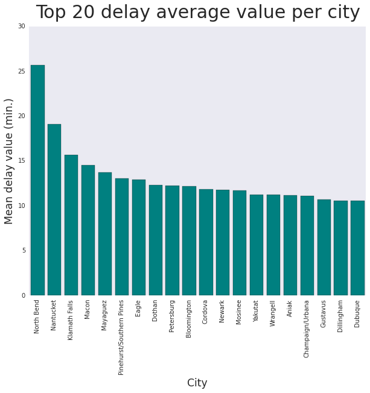

```python
x_names = query_column(top20_avg_delay_per_city, 0)
y_data = query_column(top20_avg_delay_per_city, 1)

barchart_simple("Top 20 delay average value per city", x_names, y_data, "City", "Mean delay value (min.)", xnames_rotation = 'vertical')
```

**Note**  
We have noticed that some city names in the dataframe have similar values: in particular, we can find matches like "cityName/xx" and "cityName/yy".  
We are considering these values as separated cities, assuming that the author of the dataset would have put just "cityName" to refer a same city. In case our assumptions are not met, it would have been sufficient to split these values before, taking just the first element before an eventual "/" character.  
The code implemented by us for retrieving then the information would have been the same

### Question 5.3

Is there any relationship between weather condition and the delay of flights in 1994 ?

```python
# PREPARING THE DATA TO ANALYZE THE WEATHER CORRELATION

HEADER = ["src_airport", "year", "month", "day_of_month", "temp_hig", "temp_med", "temp_low", "dew_point_hig", "dew_point_med",
          "dew_point_low", "hum_hig", "hum_med", "hum_low", "see_lev_p_hig", "see_lev_p_med", "see_lev_p_low",
          "vis_hig", "vis_med", "vis_low", "wind_hig", "wind_med", "wind_low", "precipitation", "fog",
          "rain", "snow","thunderstorm"]

# our data concerning the weather in several airports cosidering the codes appearing in AIRPORT IATA
weather = sc.textFile('./datasets/airports_weather.csv')

# extract the header
header = weather.first()

# replace invalid data with NULL and remove header
# no need to fix missing data, it's already an empty string
cleaned_data = weather.filter(lambda line: line != header)

tmp = cleaned_data.take(10)

# the structure of our Data Frame
weather_data_schema = StructType([ \
    #StructField( name, dataType, nullable)
    StructField(HEADER[0],  StringType(), True), \
    StructField(HEADER[1],  IntegerType(), True), \
    StructField(HEADER[2],  IntegerType(), True), \
    StructField(HEADER[3],  IntegerType(), True), \
    StructField(HEADER[4],  IntegerType(), True), \
    StructField(HEADER[5],  IntegerType(), True), \
    StructField(HEADER[6],  IntegerType(), True), \
    StructField(HEADER[7],  IntegerType(), True), \
    StructField(HEADER[8],  IntegerType(), True), \
    StructField(HEADER[9],  IntegerType(), True), \
    StructField(HEADER[10], IntegerType(), True), \
    StructField(HEADER[11], IntegerType(), True), \
    StructField(HEADER[12], IntegerType(), True), \
    StructField(HEADER[13], IntegerType(), True), \
    StructField(HEADER[14], IntegerType(), True), \
    StructField(HEADER[15], IntegerType(), True), \
    StructField(HEADER[16], IntegerType(), True), \
    StructField(HEADER[17], IntegerType(), True), \
    StructField(HEADER[18], IntegerType(), True), \
    StructField(HEADER[19], IntegerType(), True), \
    StructField(HEADER[20], IntegerType(), True), \
    StructField(HEADER[21], IntegerType(), True), \
    StructField(HEADER[22], IntegerType(), True), \
    StructField(HEADER[23], IntegerType(), True), \
    StructField(HEADER[24], IntegerType(), True), \
    StructField(HEADER[25], IntegerType(), True), \
    StructField(HEADER[26], IntegerType(), True), \
])


# cleaning the data in input so we can construct the Data Frame
cleaned_data_to_columns = (
    cleaned_data.map(lambda l: l.split(","))
    .map(lambda cols:
         (
            cols[0]  if cols[0] else None,
            int(cols[1])  if cols[1] else None,
            int(cols[2])  if cols[2] else None,
            int(cols[3])  if cols[3] else None,
            int(cols[4])  if cols[4] else None,
            int(cols[5])  if cols[5] else None,
            int(cols[6])  if cols[6] else None,
            int(cols[7])  if cols[7] else None,
            int(cols[8])  if cols[8] else None,
            int(cols[9])  if cols[9] else None,
            int(cols[10]) if cols[10] else None,
            int(cols[11]) if cols[11] else None,
            int(cols[12]) if cols[12] else None,
            int(cols[13]) if cols[13] else None,
            int(cols[14]) if cols[14] else None,
            int(cols[15]) if cols[15] else None,
            int(cols[16]) if cols[16] else None,
            int(cols[17]) if cols[17] else None,
            int(cols[18]) if cols[18] else None,
            int(cols[19]) if cols[19] else None,
            int(cols[20]) if cols[20] else None,
            int(cols[21]) if cols[21] else None,
            int(cols[22]) if cols[22] else None,
            int(cols[23]) if cols[23] else None,
            int(cols[24]) if cols[24] else None,
            int(cols[25]) if cols[25] else None,
            int(cols[26]) if cols[26] else None
         )
        )
)

# we select only the feature of interest
weather_airports = sqlContext.createDataFrame(cleaned_data_to_columns, weather_data_schema)\
    .select([HEADER[0],  # airport_code
             HEADER[1],  # year
             HEADER[2],  # month
             HEADER[3],  # day
             HEADER[23], # fog
             HEADER[24], # rain
             HEADER[25], # snow
             HEADER[26]  #thunderstorm
            ])\
    .cache()

weather_airports.printSchema()
```

```
root
 |-- src_airport: string (nullable = true)
 |-- year: integer (nullable = true)
 |-- month: integer (nullable = true)
 |-- day_of_month: integer (nullable = true)
 |-- fog: integer (nullable = true)
 |-- rain: integer (nullable = true)
 |-- snow: integer (nullable = true)
 |-- thunderstorm: integer (nullable = true)
```

```python
# JOINING AND CORRELATION WITH WEATHER
df_enhanced = df.join(weather_airports, ['src_airport', 'day_of_month', 'month', 'year']).cache()
```

```python
# these are the variables used to retrieve the last gridcharts
wheaters = []
global_view_days = []
global_view_months = []
```

```
+------------+-----+
|day_of_month|count|
+------------+-----+
|           1| 7501|
|           2| 7420|
|           3| 6566|
|           4| 6822|
|           5| 8165|
+------------+-----+
only showing top 5 rows
```

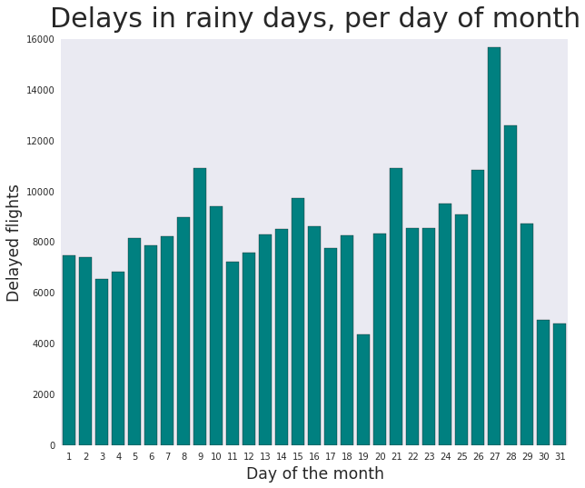

```python
# Delays per day of the month (RAIN)
delayed_per_day_of_month_rain = df_enhanced.filter((df_enhanced.arrival_delay > 15) & (df_enhanced.rain == 1)).groupBy(df_enhanced.day_of_month).count().orderBy(df_enhanced.day_of_month)
delayed_per_day_of_month_rain.show(5)

y_data = query_column(delayed_per_day_of_month_rain.collect(), 1)
barchart_simple("Delays in rainy days, per day of month", DAYS_NUMBER, y_data, "Day of the month", "Delayed flights")

wheaters.append('Rain')
global_view_days.append(y_data)
```

```
+-----+-----+
|month|count|
+-----+-----+
|    1|23867|
|    2|18245|
|    3|22520|
|    4|24255|
|    5|16493|
+-----+-----+
only showing top 5 rows
```

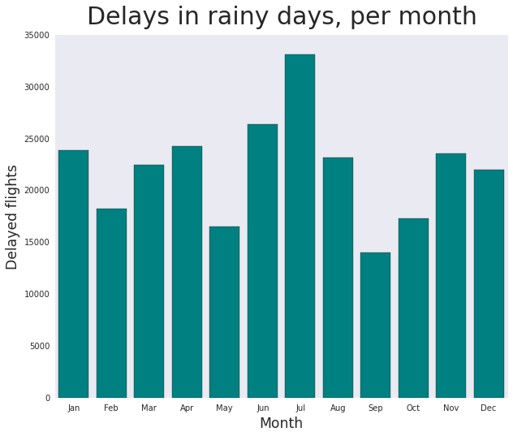

```python
# Delays per month of the year (RAIN)
delayed_per_month_rain = df_enhanced.filter((df_enhanced.arrival_delay > 15) & (df_enhanced.rain == 1)).groupBy('month').count().orderBy('month')
delayed_per_month_rain.show(5)

y_data = query_column(delayed_per_month_rain.collect(), 1)
barchart_simple("Delays in rainy days, per month", MONTHS_SHORT, y_data, "Month", "Delayed flights")

global_view_months.append(y_data)
```

```
+------------+-----+
|day_of_month|count|
+------------+-----+
|           1| 2016|
|           2| 2288|
|           3| 3181|
|           4| 1938|
|           5| 1708|
+------------+-----+
only showing top 5 rows
```

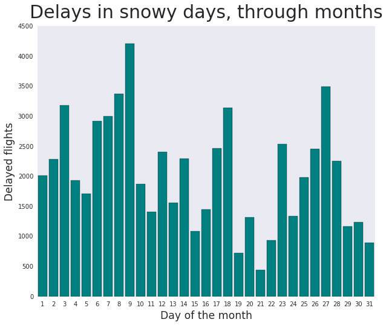

```python
# Delays per day of the month (SNOW)
delayed_per_day_of_month_snow = df_enhanced.filter((df_enhanced.arrival_delay > 15) & (df_enhanced.snow == 1)).groupBy(df_enhanced.day_of_month).count().orderBy(df_enhanced.day_of_month)
delayed_per_day_of_month_snow.show(5)

y_data = query_column(delayed_per_day_of_month_snow.collect(), 1)
barchart_simple("Delays in snowy days, through months", DAYS_NUMBER, y_data, "Day of the month", "Delayed flights")

wheaters.append('Snow')
global_view_days.append(y_data)
```